# Assignment

Amin Fadaee

September 11, 2017

We are trying to do a machine learning prediction task on pml dataset and predict for the variable `classe` which comprise of 5 ctegories of `A,B,C,D,E`. Lets load in the `caret` library and then the datasets.

```r
library(caret)
training <- read.csv('pml-training.csv')
testing <- read.csv('pml-testing.csv')
```

The `testing` data is not the data set we are going to use for testing the model we are about to use and it’s going to be deployed for predicting the quiz. So we should do some data splitting among with a little preprocessing to deal with `NA`s in our datasets:

```r
testing <- replace(testing,is.na(testing),0)
training <- replace(training,is.na(training),0)

indecies <- sample(dim(training)[1],ceiling(dim(training)[1]*0.2))
training_train <- training[-indecies,]
training_test <- training[indecies,]
```

We are going to use the `training_train` to train our model and `training_test` which is 20% of the original data to test it and obtain an **out of sample** error estimation for our prediction.

As stated in the lecrues gradient boosting machine is a good ensemble method for the task of prediction and that is the reason we are going to harness its power for our task.

The gbm is going to take a lot of time if done on the whole variables. So in order to speed it up we are going to obtain 50 principle components which will not only capture the general varience in the data but it will also help in avoiding overfitting to the training data:

```r
n = 50
pca <- preProcess(training_train,method='pca',pcaComp = n)
trainpca <- predict(pca,training_train)
trainpca <- trainpca[(dim(trainpca)[2]-n) : dim(trainpca)[2]]
trainpcatest <- predict(pca,training_test)
trainpcatest <- trainpcatest[(dim(trainpcatest)[2]-n) : dim(trainpcatest)[2]]
testpca <- predict(pca,testing)
testpca <- testpca[(dim(testpca)[2]-n+1) : dim(testpca)[2]]
```

And now lets see the parameters and plots:

```r
model
```

```
## Stochastic Gradient Boosting
##
## 15697 samples
##    50 predictor
##     5 classes: 'A', 'B', 'C', 'D', 'E'
##
## No pre-processing
## Resampling: Cross-Validated (10 fold)
## Summary of sample sizes: 14126, 14127, 14128, 14127, 14126, 14129, ...
## Resampling results across tuning parameters:
##
##   interaction.depth  n.trees  Accuracy   Kappa
##   1                   50      0.7208399  0.6443885
##   1                  100      0.7806578  0.7216925
##   1                  150      0.8108543  0.7603424
##   2                   50      0.7998352  0.7461597
##   2                  100      0.8593376  0.8218875
##   2                  150      0.8892783  0.8598781
##   3                   50      0.8414983  0.7992192
##   3                  100      0.8950766  0.8672182
##   3                  150      0.9230439  0.9026755
##
## Tuning parameter 'shrinkage' was held constant at a value of 0.1
##
## Tuning parameter 'n.minobsinnode' was held constant at a value of 10
## Accuracy was used to select the optimal model using  the largest value.
## The final values used for the model were n.trees = 150,
##  interaction.depth = 3, shrinkage = 0.1 and n.minobsinnode = 10.
```

```r
confusionMatrix(predict(model),trainpca$classe)
```

```
## Confusion Matrix and Statistics
##
##           Reference
## Prediction    A    B    C    D    E
##          A 4387  107    6    3    1
##          B   59 2787  110    5   11
##          C    9  129 2542  155   14
##          D    6    2   94 2340   60
##          E    0    4   20   64 2782
##
## Overall Statistics
##
##                Accuracy : 0.9453
##                  95% CI : (0.9416, 0.9488)
##     No Information Rate : 0.2842
##     P-Value [Acc > NIR] : < 2.2e-16
##
##                   Kappa : 0.9308
##  Mcnemar's Test P-Value : 2.895e-05
##
## Statistics by Class:
##
##                      Class: A Class: B Class: C Class: D Class: E
## Sensitivity            0.9834   0.9201   0.9170   0.9116   0.9700
## Specificity            0.9896   0.9854   0.9762   0.9877   0.9931
## Pos Pred Value         0.9740   0.9378   0.8922   0.9353   0.9693
## Neg Pred Value         0.9934   0.9810   0.9821   0.9828   0.9933
## Prevalence             0.2842   0.1930   0.1766   0.1635   0.1827
## Detection Rate         0.2795   0.1775   0.1619   0.1491   0.1772
## Detection Prevalence   0.2869   0.1893   0.1815   0.1594   0.1828
## Balanced Accuracy      0.9865   0.9528   0.9466   0.9496   0.9816
```

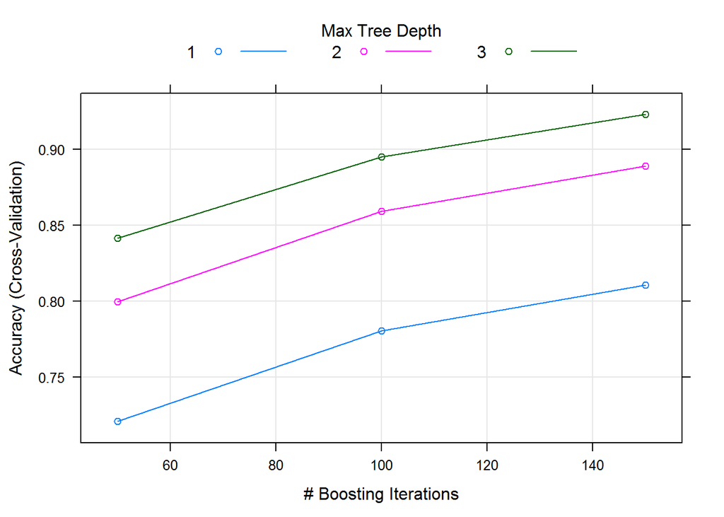

```r
plot(model)
```

but lets also test the model on `training_test` to get a general estimation of the **out of sample error**:

```r
accuracy <- sum(trainpcatest$classe == predict(model,newdata=trainpcatest[2:dim(trainpcatest)[2]]))/dim(trainpcatest)[2]
accuracy
```

[output not shown]